# Project: Investigate a Dataset (tmdb-movies dataset)

- Introduction
- Data Wrangling
- Exploratory Data Analysis
- Conclusions

## Introduction

> I'm going to showcase the data analysis steps on The Movies DB dataset , containing about 10 k movies and about 18 features for each, including several core features such as budget,revenue,genres,ratings,..etc

> We can raise several quietions :

> 1st Group --> Popularity related questions:
> 1. What are most popular movie genres through time?
> 2. who are most popular directors in the last 10 years?

> 2nd Group --> Revenue related questions:
> 1. What kinds of properties are associated with movies that have high revenues?
> 2. How do revenue and budget correlate?
> 3. Does series movies revenue increase/decrease for each new chapter?

```python
import pandas as pd
import numpy as np
import matplotlib.pyplot as plt
import seaborn as sns
% matplotlib inline
```

## Data Wrangling

### General Properties

```python
df = pd.read_csv('tmdb-movies.csv')
df.head(3)
```

|  | id | imdb_id | popularity | budget | revenue | original_title | cast | homepage | director | tagline | ... | overview | runtime | genres | production_companies | release_date | vote_count | vote_average | release_year | budget_adj | revenue_adj |
| --- | --- | --- | --- | --- | --- | --- | --- | --- | --- | --- | --- | --- | --- | --- | --- | --- | --- | --- | --- | --- | --- |
| 0 | 135397 | tt0369610 | 32.985763 | 150000000 | 1513528810 | Jurassic World | Chris Pratt\|Bryce Dallas Howard\|Irrfan Khan\|Vi... | http://www.jurassicworld.com/ | Colin Trevorrow | The park is open. | ... | Twenty-two years after the events of Jurassic ... | 124 | Action\|Adventure\|Science Fiction\|Thriller | Universal Studios\|Amblin Entertainment\|Legenda... | 6/9/15 | 5562 | 6.5 | 2015 | 1.379999e+08 | 1.392446e+09 |
| 1 | 76341 | tt1392190 | 28.419936 | 150000000 | 378436354 | Mad Max: Fury Road | Tom Hardy\|Charlize Theron\|Hugh Keays-Byrne\|Nic... | http://www.madmaxmovie.com/ | George Miller | What a Lovely Day. | ... | An apocalyptic story set in the furthest reach... | 120 | Action\|Adventure\|Science Fiction\|Thriller | Village Roadshow Pictures\|Kennedy Miller Produ... | 5/13/15 | 6185 | 7.1 | 2015 | 1.379999e+08 | 3.481613e+08 |
| 2 | 262500 | tt2908446 | 13.112507 | 110000000 | 295238201 | Insurgent | Shailene Woodley\|Theo James\|Kate Winslet\|Ansel... | http://www.thedivergentseries.movie/#insurgent | Robert Schwentke | One Choice Can Destroy You | ... | Beatrice Prior must confront her inner demons ... | 119 | Adventure\|Science Fiction\|Thriller | Summit Entertainment\|Mandeville Films\|Red Wago... | 3/18/15 | 2480 | 6.3 | 2015 | 1.012000e+08 | 2.716190e+08 |

3 rows × 21 columns

```
                  id    popularity        budget       revenue       runtime  \
count   10866.000000  10866.000000  1.086600e+04  1.086600e+04  10866.000000
mean    66064.177434      0.646441  1.462570e+07  3.982332e+07    102.070863
std     92130.136561      1.000185  3.091321e+07  1.170035e+08     31.381405
min         5.000000      0.000065  0.000000e+00  0.000000e+00      0.000000
25%     10596.250000      0.207583  0.000000e+00  0.000000e+00     90.000000
50%     20669.000000      0.383856  0.000000e+00  0.000000e+00     99.000000
75%     75610.000000      0.713817  1.500000e+07  2.400000e+07    111.000000
max    417859.000000     32.985763  4.250000e+08  2.781506e+09    900.000000

         vote_count  vote_average  release_year    budget_adj   revenue_adj
count  10866.000000  10866.000000  10866.000000  1.086600e+04  1.086600e+04
mean     217.389748      5.974922   2001.322658  1.755104e+07  5.136436e+07
std      575.619058      0.935142     12.812941  3.430616e+07  1.446325e+08
min       10.000000      1.500000   1960.000000  0.000000e+00  0.000000e+00
25%       17.000000      5.400000   1995.000000  0.000000e+00  0.000000e+00
50%       38.000000      6.000000   2006.000000  0.000000e+00  0.000000e+00
75%      145.750000      6.600000   2011.000000  2.085325e+07  3.369710e+07
max     9767.000000      9.200000   2015.000000  4.250000e+08  2.827124e+09
<class 'pandas.core.frame.DataFrame'>
RangeIndex: 10866 entries, 0 to 10865
Data columns (total 21 columns):
id                      10866 non-null int64
imdb_id                 10856 non-null object
popularity              10866 non-null float64
budget                  10866 non-null int64
revenue                 10866 non-null int64
original_title          10866 non-null object
cast                    10790 non-null object
homepage                2936 non-null object
director                10822 non-null object
tagline                 8042 non-null object
keywords                9373 non-null object
overview                10862 non-null object
runtime                 10866 non-null int64
genres                  10843 non-null object
production_companies    9836 non-null object
release_date            10866 non-null object
vote_count              10866 non-null int64
vote_average            10866 non-null float64
```

[output cut: 14 more lines]

```
homepage                 2896
director                 5067
tagline                  7997
keywords                 8804
overview                10847
runtime                   247
genres                   2039
production_companies     7445
release_date             5909
vote_count               1289
vote_average               72
release_year               56
budget_adj               2614
revenue_adj              4840
dtype: int64
```

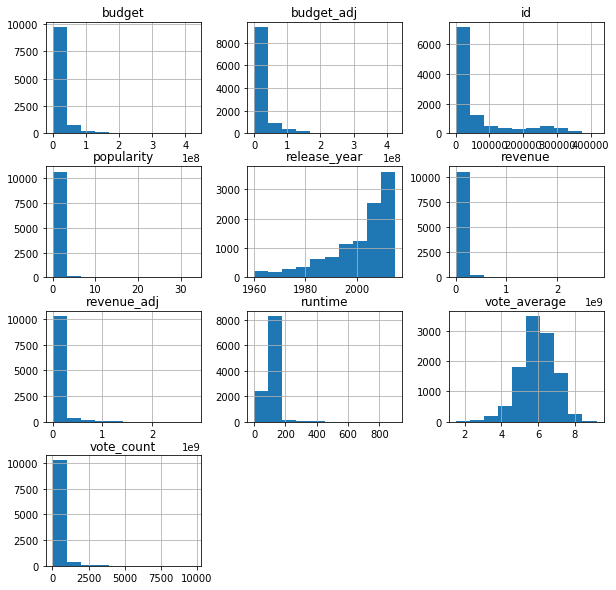

```python
#quick analysis overview
print(df.describe())
print(df.info())
print("unique values :\n",df.nunique())
print(df.hist(figsize=(10,10)))
```

```python
#it seems that more than 50% of budget & revenue data is set to Zero, let's check the count of zero values exactly
print("Number of movies with zeroed budget:",df[df['budget_adj'] == 0].budget_adj.count())
print("Number of movies with zeroed revenue:",df[df['revenue_adj'] == 0].budget_adj.count())
```

```
Number of movies with zeroed budget: 5696
Number of movies with zeroed revenue: 6016
```

```python
#in runtime columns there is a value of 900 mins , i'm so curious to find that 15-hours movie !
df[df['runtime'] == 900]
```

|  | id | imdb_id | popularity | budget | revenue | original_title | cast | homepage | director | tagline | ... | overview | runtime | genres | production_companies | release_date | vote_count | vote_average | release_year | budget_adj | revenue_adj |
| --- | --- | --- | --- | --- | --- | --- | --- | --- | --- | --- | --- | --- | --- | --- | --- | --- | --- | --- | --- | --- | --- |
| 3894 | 125336 | tt2044056 | 0.006925 | 0 | 0 | The Story of Film: An Odyssey | Mark Cousins\|Jean-Michel Frodon\|Cari Beauchamp... | http://www.channel4.com/programmes/the-story-o... | Mark Cousins | NaN | ... | The Story of Film: An Odyssey, written and dir... | 900 | Documentary | NaN | 9/3/11 | 14 | 9.2 | 2011 | 0.0 | 0.0 |

1 rows × 21 columns

**descriptive statistics and histograms findings:**

1. There are 5696 zero-budget records and 6016 zero-revenue records , means that more than half of data has zero budget/revenue values , it's not logic that all this portion represents indei(self-funded) movies  
   *Action* :so,we would remove this zero-values when answering any revenue/budget related questions
1. There are some clear outliers such as :A) in popularity column the 32.9 value is clearly out of range as almost 90% of values lies below 1. B)the runtime column has a value of 900 mins (15 hours !) sound a so clear outlier , but fter investigation, it was a 15-episode documentary about history of film which sounds a little bit wrongly found in this "Movies" dataset  
   *Action* : for popularity related questions i will depend on the vote_avg column as it has clear scaling (10 degree scale raings) unlike the popularity column have diverse numbers with no clear scale or criteria.
1. More than 50% of dataset's movies are within the last 10 years while it cover a span time of 55 years.  
   *Action* : so it sounds logic to have some popularity related analytics over the last 10 years only.

**Dataset info and header findings:**

1. Release date column type should be tranformed to date as it's an object "string"
2. Most columns that have significant count of null values are the less important columns and to be trimmed such as : *hompage , tagline, overview, keywords*

### Data Cleaning

```python
#trim the unrequired columns from the dataset
df.drop(['id', 'imdb_id','homepage','tagline','overview','keywords','revenue','budget','production_companies'], axis = 1, inplace = True)
df.head(1)
#notice that removing budget and revenue column as our main focus would be on revenue_adj and budget_adj as they consider the
#inflation rate through time
```

|  | popularity | original_title | cast | director | runtime | genres | release_date | vote_count | vote_average | release_year | budget_adj | revenue_adj |
| --- | --- | --- | --- | --- | --- | --- | --- | --- | --- | --- | --- | --- |
| 0 | 32.985763 | Jurassic World | Chris Pratt\|Bryce Dallas Howard\|Irrfan Khan\|Vi... | Colin Trevorrow | 124 | Action\|Adventure\|Science Fiction\|Thriller | 6/9/15 | 5562 | 6.5 | 2015 | 1.379999e+08 | 1.392446e+09 |

```python
#finding null values
df.isnull().sum()
```

```
popularity         0
original_title     0
cast              76
director          44
runtime            0
genres            23
release_date       0
vote_count         0
vote_average       0
release_year       0
budget_adj         0
revenue_adj        0
dtype: int64
```

```python
#as null values count isn't a big deal and wouldn't have a significant impact on analysis if removed
#so we remove null values
df.dropna(inplace= True)
df.isnull().sum()
```

```
popularity        0
original_title    0
cast              0
director          0
runtime           0
genres            0
release_date      0
vote_count        0
vote_average      0
release_year      0
budget_adj        0
revenue_adj       0
dtype: int64
```

```python
#finding number of duplicate rows
display(df.duplicated().sum())
```

```
1
```

```python
#As expected, almost there is no duplicates , it's supposed to have a row per movie while this single row may be added by misr
#However,let's remove this single duplication
df.drop_duplicates(inplace = True)
display(df.duplicated().sum())
```

```
0
```

```python
#tranforming release date column to a datetime format
type(df['release_date'][0])
```

```
str
```

```python
df['release_date'] = pd.to_datetime(df.release_date)
type(df['release_date'][0])
```

```
pandas._libs.tslibs.timestamps.Timestamp
```

```python
#also after seeing dataset info , it seems that revenue and budget(floats) needs to be (int)
print(type(df['revenue_adj'][0]),type(df['budget_adj'][0]))
```

```
<class 'numpy.float64'> <class 'numpy.float64'>
```

```python
#converting both values to int64
df['revenue_adj'] = df['revenue_adj'].astype('int64')
df['budget_adj'] = df['budget_adj'].astype('int64')
```

```python
#let's check now how does the dataset look after preprocessing
df.info()
df.head()
#we could notice that revenue and budget columns have been transformed
```

```
<class 'pandas.core.frame.DataFrame'>
Int64Index: 10731 entries, 0 to 10865
Data columns (total 12 columns):
popularity        10731 non-null float64
original_title    10731 non-null object
cast              10731 non-null object
director          10731 non-null object
runtime           10731 non-null int64
genres            10731 non-null object
release_date      10731 non-null datetime64[ns]
vote_count        10731 non-null int64
vote_average      10731 non-null float64
release_year      10731 non-null int64
budget_adj        10731 non-null int64
revenue_adj       10731 non-null int64
dtypes: datetime64[ns](1), float64(2), int64(5), object(4)
memory usage: 1.4+ MB
```

|  | popularity | original_title | cast | director | runtime | genres | release_date | vote_count | vote_average | release_year | budget_adj | revenue_adj |
| --- | --- | --- | --- | --- | --- | --- | --- | --- | --- | --- | --- | --- |
| 0 | 32.985763 | Jurassic World | Chris Pratt\|Bryce Dallas Howard\|Irrfan Khan\|Vi... | Colin Trevorrow | 124 | Action\|Adventure\|Science Fiction\|Thriller | 2015-06-09 | 5562 | 6.5 | 2015 | 137999939 | 1392445892 |
| 1 | 28.419936 | Mad Max: Fury Road | Tom Hardy\|Charlize Theron\|Hugh Keays-Byrne\|Nic... | George Miller | 120 | Action\|Adventure\|Science Fiction\|Thriller | 2015-05-13 | 6185 | 7.1 | 2015 | 137999939 | 348161292 |
| 2 | 13.112507 | Insurgent | Shailene Woodley\|Theo James\|Kate Winslet\|Ansel... | Robert Schwentke | 119 | Adventure\|Science Fiction\|Thriller | 2015-03-18 | 2480 | 6.3 | 2015 | 101199955 | 271619025 |
| 3 | 11.173104 | Star Wars: The Force Awakens | Harrison Ford\|Mark Hamill\|Carrie Fisher\|Adam D... | J.J. Abrams | 136 | Action\|Adventure\|Science Fiction\|Fantasy | 2015-12-15 | 5292 | 7.5 | 2015 | 183999919 | 1902723129 |
| 4 | 9.335014 | Furious 7 | Vin Diesel\|Paul Walker\|Jason Statham\|Michelle ... | James Wan | 137 | Action\|Crime\|Thriller | 2015-04-01 | 2947 | 7.3 | 2015 | 174799923 | 1385748801 |

## Exploratory Data Analysis

### Popularity Related Quetions:

### 1. What are most popular movie genres through time?

```python
# As we see , genres columns has multiple values separated with "|" which needs to be handled
df['genres'][0]
```

```
'Action|Adventure|Science Fiction|Thriller'
```

```python
def sep_top(df,col,n):

    """
    Takes a df column(col) with mulitple stick seprarated values
    and returns a list of unique top (n) frequent values
    """
    #will take a column, and separate the string by '|'
    data = df[col].str.cat(sep = '|')

    #get a pandas series storing separate values
    data = pd.Series(data.split('|'))

    #get unique to n frequent values
    data = data.value_counts()[:n].index.tolist()


    return data
```

```python
def get_vote(data):

    """
    Takes a list of unique items
    gets the average voting per item in a sorted dataframe
    """
    #create a dic
    dict_df = {key:[] for key in data}
    #update dict with average voting for every genre(key)
    for word in data:
        vote = df[df.genres.str.contains(word)].vote_average.mean()
        dict_df[word].append(vote)
    #get the DF of the dict
    new_df = pd.DataFrame.from_dict(dict_df)
    new_df = new_df.T
    new_df.columns = ['avg_vote']
    new_df.sort_values(['avg_vote'],ascending = False, inplace = True)
    return new_df
```

```python
#let's get the top 10 frequent genres in the last 10 years
genre_top = sep_top(df,'genres',10)
genre_top
```

```
['Drama',
 'Comedy',
 'Thriller',
 'Action',
 'Romance',
 'Horror',
 'Adventure',
 'Crime',
 'Science Fiction',
 'Family']
```

```python
#let's see which is most popular
get_vote(genre_top)
```

|  | avg_vote |
| --- | --- |
| Drama | 6.163611 |
| Crime | 6.124982 |
| Romance | 6.042213 |
| Family | 5.986903 |
| Adventure | 5.935427 |
| Comedy | 5.900927 |
| Action | 5.784891 |
| Thriller | 5.750310 |
| Science Fiction | 5.657576 |
| Horror | 5.337714 |

**As shown , the answer to the 1st Quation "What are most popular movie genres through time?" is clearly Drama , then Crime comes secondly**

### 2. who are most popular directors in the last 10 years?

```python
#let's filter data for last 10 years
df_last10= df[df['release_year']>=2005]
df_last10.info()
```

```
<class 'pandas.core.frame.DataFrame'>
Int64Index: 5737 entries, 0 to 7824
Data columns (total 12 columns):
popularity        5737 non-null float64
original_title    5737 non-null object
cast              5737 non-null object
director          5737 non-null object
runtime           5737 non-null int64
genres            5737 non-null object
release_date      5737 non-null datetime64[ns]
vote_count        5737 non-null int64
vote_average      5737 non-null float64
release_year      5737 non-null int64
budget_adj        5737 non-null int64
revenue_adj       5737 non-null int64
dtypes: datetime64[ns](1), float64(2), int64(5), object(4)
memory usage: 582.7+ KB
```

```python
#filter on directors with more than 2 movies, to have a more realitic and indicating average vote
df_last10 = df_last10.groupby("director").filter(lambda x: len(x) >= 3)
df_last10.director.count()
```

```
2000
```

```python
df_last10.groupby("director").vote_average.mean().sort_values(ascending = False)[:10]
```

```
director
Christopher Nolan     7.766667
Louis C.K.            7.750000
Paul Dugdale          7.733333
Quentin Tarantino     7.520000
Shannon Hartman       7.520000
Wes Anderson          7.383333
Giuseppe Tornatore    7.366667
Joss Whedon           7.360000
Jay Karas             7.350000
Angus MacLane         7.333333
Name: vote_average, dtype: float64
```

**as shown , the answer to the 2nd question" who are most popular directors in the last 10 years?", is C.Nolan which is not a surprise , and seeing Nolan & Tarantino in top 5 can assure that we are going in the right way :)**

### Revenue Related Quetions:

### 1. What kinds of properties are associated with movies that have high revenues?

```python
#first we want to remove zero value revenues and budget
df_rev = df.drop(df[df.revenue_adj == 0].index)
df_rev = df_rev.drop(df_rev[df_rev.budget_adj == 0].index)
df_rev.info()
```

```
<class 'pandas.core.frame.DataFrame'>
Int64Index: 3848 entries, 0 to 10848
Data columns (total 12 columns):
popularity        3848 non-null float64
original_title    3848 non-null object
cast              3848 non-null object
director          3848 non-null object
runtime           3848 non-null int64
genres            3848 non-null object
release_date      3848 non-null datetime64[ns]
vote_count        3848 non-null int64
vote_average      3848 non-null float64
release_year      3848 non-null int64
budget_adj        3848 non-null int64
revenue_adj       3848 non-null int64
dtypes: datetime64[ns](1), float64(2), int64(5), object(4)
memory usage: 390.8+ KB
```

[output not shown]

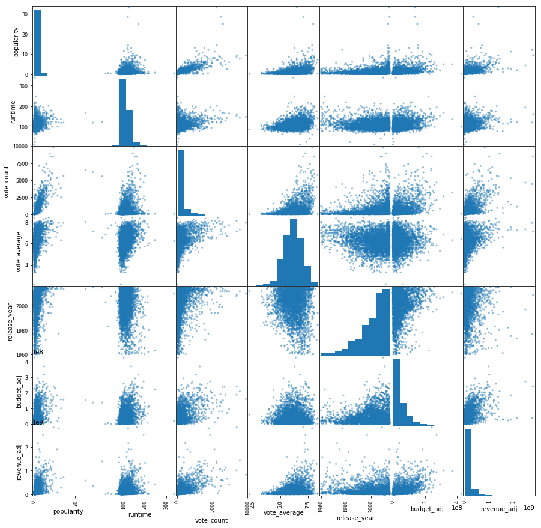

```python
#let's draw a scatter plot matrix to have a quick look at features association
pd.plotting.scatter_matrix(df_rev, figsize=(15,15))
```

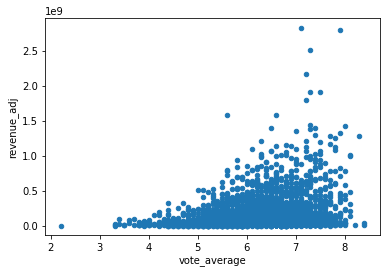

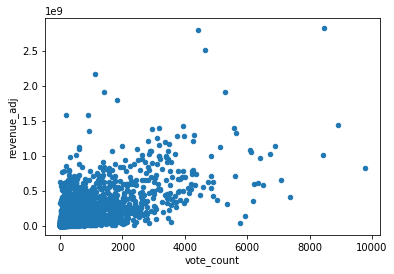

```python
#looking at the scatter matrix , the most two revenue-associated features are vote_average and vote_count
#so, let's check them with revenue individualy
df_rev.plot.scatter(x='vote_average',y='revenue_adj')
df_rev.plot.scatter(x='vote_count',y='revenue_adj')
```

#### The Answer to the 3rd question" What kinds of properties are associated with movies that have high revenues?" is clearly voting features , as almost all high revenue movies have high ratings (and not vice versa).

#### This does't deny that there a high-rated movies with low budgets

### 2.How do revenue and budget correlate?

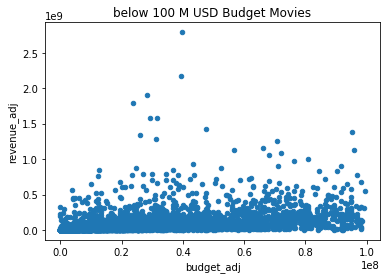

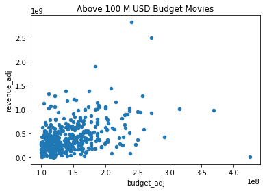

```python
#let's plot the relation between revenue and budgest , splitting this around the 100M$ budgets to have a closer look
df_rev[df_rev['budget_adj'] < 100000000].plot.scatter(x='budget_adj',y='revenue_adj',title = 'below 100 M USD Budget Movies')
df_rev[df_rev['budget_adj'] >= 100000000].plot.scatter(x='budget_adj',y='revenue_adj',title = 'Above 100 M USD Budget Movies')
```

```python
#at the 2nd plot(above 100 M USD) there is a very interesting point, a movie with a more than 400 M USD budget achieving about
#10 M USD of revenue, which is very weird . so let's check this record
df_rev[df_rev['budget_adj'] > 400000000]
```

|  | popularity | original_title | cast | director | runtime | genres | release_date | vote_count | vote_average | release_year | budget_adj | revenue_adj |
| --- | --- | --- | --- | --- | --- | --- | --- | --- | --- | --- | --- | --- |
| 2244 | 0.25054 | The Warrior's Way | Kate Bosworth\|Jang Dong-gun\|Geoffrey Rush\|Dann... | Sngmoo Lee | 100 | Adventure\|Fantasy\|Action\|Western\|Thriller | 2010-12-02 | 74 | 6.4 | 2010 | 425000000 | 11087569 |

**Accodring to wikipedia , this movie's budget is only 42M and not 425M as in dataset , so it's a typo in the values**

https://en.wikipedia.org/wiki/The_Warrior%27s_Way

#### Answering the 4th Question "How do revenue and budget correlate?", it's found out that there is no clear correlation between budget and revenue as several low-budget movies acheived higher revenue than high-budget movies

### 3.Does series movies revenue increase/decrease for each new chapter?

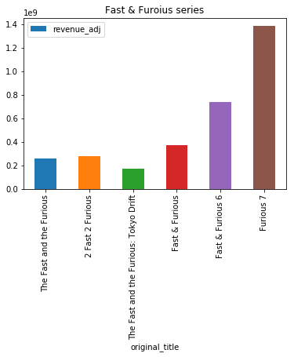

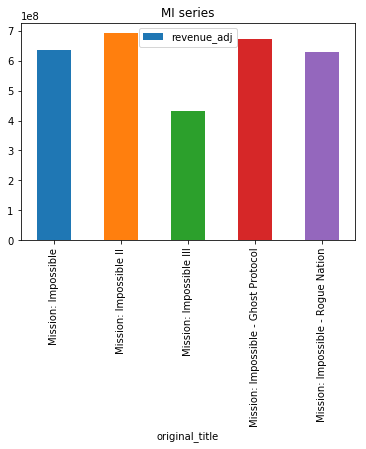

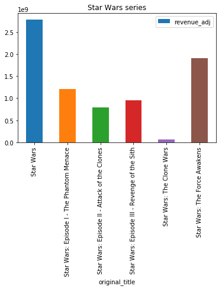

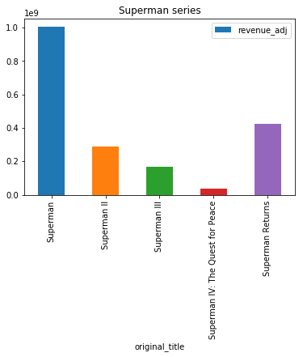

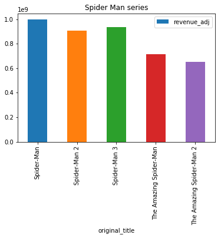

```python
#checking the revenue of 5 well-known movie-series sorted , each chart is sorted by release year
df_rev_fur = df_rev[df_rev.original_title.str.contains('Furious')]
df_rev_fur.sort_values('release_year').plot.bar(x='original_title',y='revenue_adj',title = "Fast & Furoius series")
df_rev_mi = df_rev[df_rev.original_title.str.contains('Mission: Impo')]
df_rev_mi.sort_values('release_year').plot.bar(x='original_title',y='revenue_adj',title = "MI series")
df_rev_sw = df_rev[df_rev.original_title.str.contains('Star Wars')]
df_rev_sw.sort_values('release_year').plot.bar(x='original_title',y='revenue_adj',title = "Star Wars series")
df_rev_bat = df_rev[df_rev.original_title.str.contains('Superman')]
df_rev_bat.sort_values('release_year').plot.bar(x='original_title',y='revenue_adj',title = "Superman series")
df_rev_sp = df_rev[df_rev.original_title.str.contains('Spider-Man')]
df_rev_sp.sort_values('release_year').plot.bar(x='original_title',y='revenue_adj',title = "Spider Man series")
```

## Conclusions

### Popularity related questions:

1. For the most popular Movie Genres , after working on nearly whole dataset whithout any filtters ,i used the vote_average to measure popularity instead of "popularity" column as it has no clear measure criteria or scale , it showed that drama comes first and crime as scond and the third was romance, this could lead us that people are mainly attracted by targeting their feelings and challenging their minds!
1. For most popular directors , i have filter to the last 10 years(reduce count to 5.5k) to be more specific and have more meanningful resutls , then filtering on directors with more than 2 movies(count become 2 k) , to have a sensible & comparable average voting for every director , finding out C.Nolan on top which is a very logic result with his unique sense in film making also with his masterpiece "Interstellar" in 2014.

### Limitaions:

1. having more than half of the dataset with zero values in budget and revenue which should affect negatively on the quality of analysis related to revenue & budget
2. having some issues values in the dataset like the values of movie-budget which has a typo, a few of this issues could affect the overall analysis
3. i had to use the vote_average column to measure popularity as the "popularity" column given has no clear criteria of mesurement , so i coudln't depend on it

```python
from subprocess import call
call(['python', '-m', 'nbconvert', 'Investigate_a_Dataset.ipynb'])
```